# Anscombe_quartet

# 1 Quarteto de anscombe

Primeiramente, para iniciarmos nossa ambientação em R, devemos começar adicionando e abrindo as bibliotecas que usaremos, as quais são: datasets e tidyverse. Dentro do biblioteca do Tidyverse, usaremos em específico o pacote do ggplot2, assim, abriremos apenas ele. È imporatante ressaltar que o ggplot é a farramenta que irá nos facilitar visualizar os dados, e o pacote datasets importante a tabela como os dados do quarteto de Anscombe. Para isso, usaremos os seguintes comandos:

```r
#install.packages("tidyverse")
#install.packages("datasets")
#install.packages("gridExtra")
library(ggplot2)
library(datasets)
library(gridExtra)
```

## 1.1 Visulizando a tabela

Para plotarmos a tabela com o quarteto de Anscombe para visualizar os valores da tabela, utilizaremos:

```r
datasets:: anscombe
```

```
##    x1 x2 x3 x4    y1   y2    y3    y4
## 1  10 10 10  8  8.04 9.14  7.46  6.58
## 2   8  8  8  8  6.95 8.14  6.77  5.76
## 3  13 13 13  8  7.58 8.74 12.74  7.71
## 4   9  9  9  8  8.81 8.77  7.11  8.84
## 5  11 11 11  8  8.33 9.26  7.81  8.47
## 6  14 14 14  8  9.96 8.10  8.84  7.04
## 7   6  6  6  8  7.24 6.13  6.08  5.25
## 8   4  4  4 19  4.26 3.10  5.39 12.50
## 9  12 12 12  8 10.84 9.13  8.15  5.56
## 10  7  7  7  8  4.82 7.26  6.42  7.91
## 11  5  5  5  8  5.68 4.74  5.73  6.89
```

Vamos ver o que acontece com a média de x, com a variância de x em cada um dos casos

```r
mean(anscombe$x1)
```

```
## [1] 9
```

```r
mean(anscombe$x2)
```

```
## [1] 9
```

```r
mean(anscombe$x3)
```

```
## [1] 9
```

```r
mean(anscombe$x4)
```

```
## [1] 9
```

```r
sd(anscombe$x1)
```

```
## [1] 3.316625
```

```r
sd(anscombe$x2)
```

```
## [1] 3.316625
```

```r
sd(anscombe$x3)
```

```
## [1] 3.316625
```

```r
sd(anscombe$x4)
```

```
## [1] 3.316625
```

Note que a média de X e que o desvio padrão de X é o mesmo. Vamos ver se isso vale também para o eixo y?

```r
mean(anscombe$y1)
```

```
## [1] 7.500909
```

```r
mean(anscombe$y2)
```

```
## [1] 7.500909
```

```r
mean(anscombe$y3)
```

```
## [1] 7.5
```

```r
mean(anscombe$y4)
```

```
## [1] 7.500909
```

```r
sd(anscombe$y1)
```

```
## [1] 2.031568
```

```r
sd(anscombe$y2)
```

```
## [1] 2.031657
```

```r
sd(anscombe$y3)
```

```
## [1] 2.030424
```

```r
sd(anscombe$y4)
```

```
## [1] 2.030579
```

São todos aproximadamente o mesmo. Podemos calcular também a correlação entre x e y, em cada um dos gráficos, temos assim:

```r
cor(anscombe$x1, anscombe$y1)
```

```
## [1] 0.8164205
```

```r
cor(anscombe$x2, anscombe$y2)
```

```
## [1] 0.8162365
```

```r
cor(anscombe$x3, anscombe$y3)
```

```
## [1] 0.8162867
```

```r
cor(anscombe$x4, anscombe$y4)
```

```
## [1] 0.8165214
```

A correlação deles também é igual! Utilizando apenas esses gráficos, podemos pensar que como essas medidas de resumo são muito parecidas, seus gráficos tendem a ser ao menos parecidos. Será que isso é verdade? Vamos descobrir isso com o visualização do quarteto presente nesse trabalho.

## 1.2 Criando o primeiro gráfico

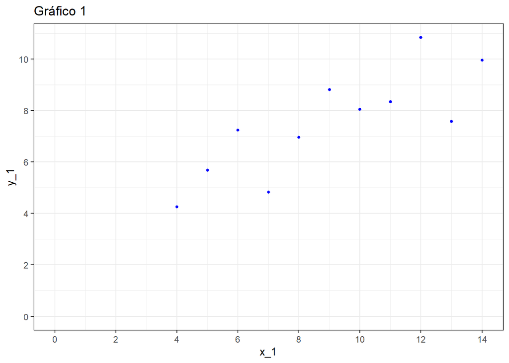

```r
graf_1 <- ggplot(data = anscombe, mapping = aes(x=x1, y=y1)) +
  scale_x_continuous(breaks = seq(0,20,2)) +
  scale_y_continuous(breaks = seq(0,14,2)) +
  expand_limits(x=0, y=0) +
  labs(x="x_1", y="y_1", title = "Gráfico 1") +
  geom_point(color = "blue", size = 1) +
  theme_bw()
graf_1
```

## 1.3 Criando os outros três gráficos

Faremos os outros três gráficos análogo ao item anterior, apenas trocando as colunas e os nomes dos eixos:

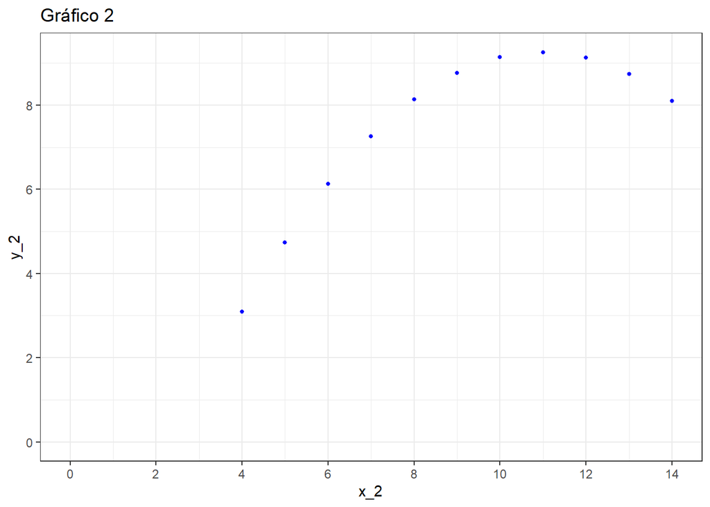

```r
graf_2 <- ggplot(data = anscombe, mapping = aes(x=x2, y=y2)) +
  scale_x_continuous(breaks = seq(0,20,2)) +
  scale_y_continuous(breaks = seq(0,14,2)) +
  expand_limits(x=0, y=0) +
  labs(x="x_2", y="y_2", title = "Gráfico 2") +
  geom_point(color = "blue", size = 1) +
  theme_bw()
graf_2
```

Gráfico 3

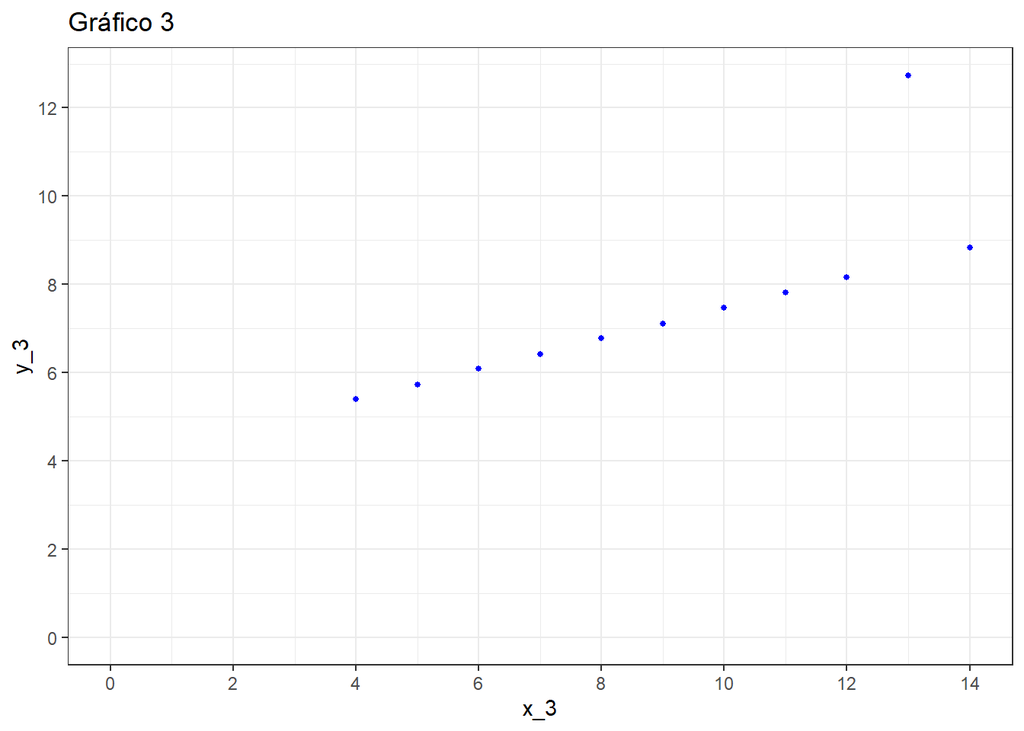

```r
graf_3 <- ggplot(data = anscombe, mapping = aes(x=x3, y=y3)) +    scale_x_continuous(breaks = seq(0,20,2)) +    scale_y_continuous(breaks = seq(0,14,2)) +    expand_limits(x=0, y=0) +    labs(x="x_3", y="y_3", title = "Gráfico 3") +    geom_point(color = "blue", size = 1) + theme_bw()
graf_3
```

Gráfico 4

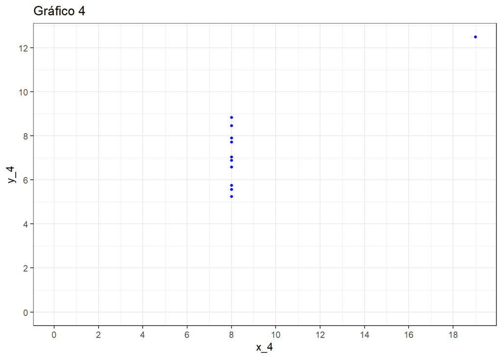

```r
graf_4 <- ggplot(data = anscombe, mapping = aes(x=x4, y=y4)) +    scale_x_continuous(breaks = seq(0,20,2)) +    scale_y_continuous(breaks = seq(0,14,2)) +    expand_limits(x=0, y=0) +    labs(x="x_4", y="y_4", title = "Gráfico 4") +    geom_point(color = "blue", size = 1) + theme_bw()
graf_4
```

## 1.4 Adicionando regressão linear

Apesar de nossa visualização estar boa, podemos melhorá-la adicionando as retas de regressão linear, para isso, utilizaremos a função lm para nos retornar a reta que melhor se ajusta:

```r
lm_1 <- lm(y1~x1, data = anscombe)
lm_2 <- lm(y2~x2, data = anscombe)
lm_3 <- lm(y3~x3, data = anscombe)
lm_4 <- lm(y4~x4, data = anscombe)
```

A partir de agora os coeficientes das retas já estão armazenados, nas variáveis, e agora fica fácil de acessa-los. Por fim, basta plotar a linha no gráfico.

```r
graf_1_reta <- graf_1 + geom_abline(intercept = coef(lm_1)[1], slope = coef(lm_1)[2], color = "red")
graf_2_reta <- graf_2 + geom_abline(intercept = coef(lm_2)[1], slope = coef(lm_2)[2], color = "red")
graf_3_reta <- graf_3 + geom_abline(intercept = coef(lm_3)[1], slope = coef(lm_3)[2], color = "red")
graf_4_reta <- graf_4 + geom_abline(intercept = coef(lm_4)[1], slope = coef(lm_4)[2], color = "red")
```

## 1.5 Juntando os quatro gráficos

Para juntar os quatro gráficos, vamos utilizar a função grid.arrange a qual vai juntar os quatro gráficos produzidos numa imagem só. Para isso utilizaremos:

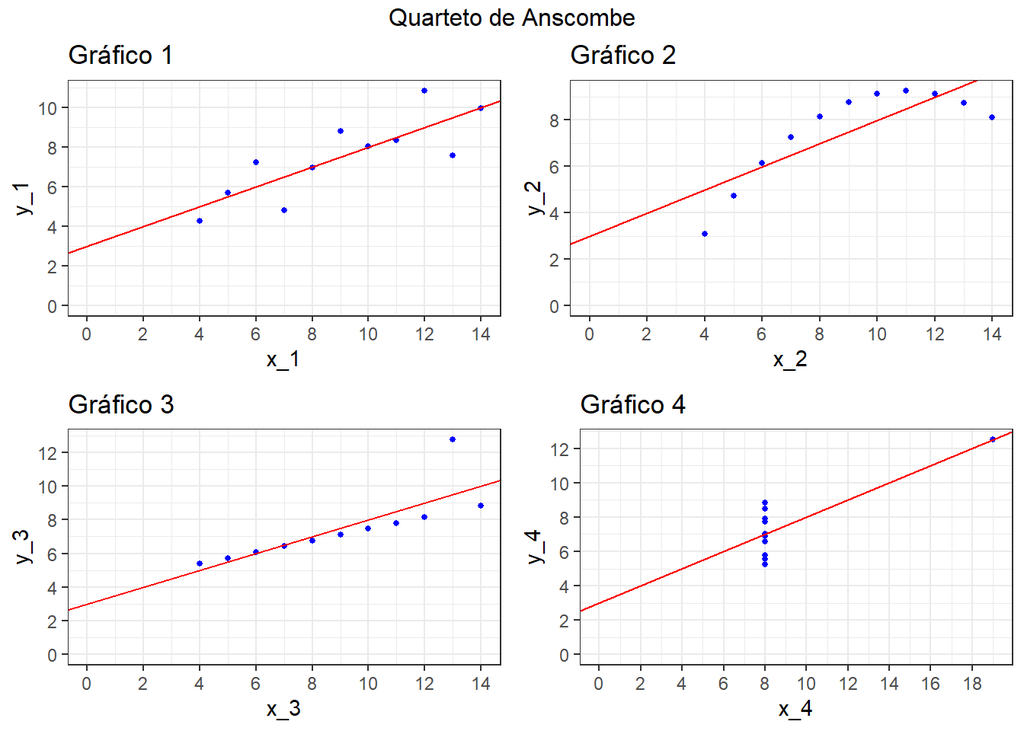

```r
grid.arrange(grobs = list(graf_1_reta, graf_2_reta, graf_3_reta, graf_4_reta), ncol(2), top = "Quarteto de Anscombe")
```

Temos assim uma visualização do quarteto de anscombe. Essa visualiação contraria nossa teoria inicial de que como as medidas de resumo são parecidas, seus gráficos tendem a ser parecidos. Concluimos assim que sempre há perda de informção quando medidas de resumo são apresentadas e uma visualização sempre é importante para entender a totalidade dos dados apresentados.